# Actividades prácticas relacionadas con la gestión de la calidad

```python
from google.colab import drive
drive.mount('/content/drive/')
```

```python
def ensure_and_move_to_folder(folder_name):
  current_dir = os.getcwd()
  target_path = os.path.join(current_dir, folder_name)

  if not os.path.exists(target_path):
    os.makedirs(target_path)
    print(f"Folder '{folder_name}' created successfully.")
  else:
    print(f"Folder '{folder_name}' already exists.")

  #os.chdir(target_path)
```

```python
import os

folder_name = 'QC_Kentei'
ensure_and_move_to_folder(folder_name)

path = os.getcwd()
try:
  os.chdir(path + '/drive/My Drive/QC_Kentei')
except:
  pass

os.getcwd()
```

```
Folder 'QC_Kentei' created successfully.
```

```
'/content/drive/My Drive/QC_Kentei'
```

```python
!pip install japanize-matplotlib
```

[output not shown]

```python
import numpy as np
import pandas as pd
import matplotlib.pyplot as plt
import japanize_matplotlib
import pandas as pd

import gspread

from google.colab import auth
auth.authenticate_user()

from google.auth import default
creds, _ = default()

gc = gspread.authorize(creds)

from gspread_dataframe import get_as_dataframe, set_with_dataframe
```

## 5.6 Análisis del punto de equilibrio

ある金型製造業では、固定費が３億円で、変動費率が0.4である。損益分岐点いくらか。

また、利益を０．６億円にするには、売り上げをいくらにしなければならないか。

En una empresa de fabricación de moldes, los costo fijos son de 300 millones de yenes y la tasa de costos vaiables es de 0.4. ¿Quál es el punto de equilibrio?

Además, ¿cuánto debe ser la venta para obtener una ganancia de 60 millones de yenes?

```python
# Costos fijos, Tasa de costors variables, Beneficio objetivo
fixed_cost = 300  # Costos fijos
variable_cost_rate = 0.4  # Tasa de costos variables
target_profit = 60  # Beneficio objetivo

# Calcular las ventas en punto de equilibrio
break_even_sales = fixed_cost / (1 - variable_cost_rate)
print(f'Las ventas en punto de equilibrio: {break_even_sales:.2f} millones')

# Calcular las ventas necesarios para alcanzar el beneficio objetivo
required_sales_for_target_profit = (fixed_cost + target_profit) / (1 - variable_cost_rate)
print(f'Las ventas necesarias para obtener un beneficio de {target_profit:.2f} millones: {required_sales_for_target_profit:.2f} millones')

# Los nuevos costos fijos después de reducir 10 millones
new_fixed_cost = fixed_cost - 10

# Calcular la nueva tasa de costos variables para alcanzaar el beneficio objetivo
# Las ventas se mantendrán en el nivel del punto de equilibrio
new_break_even_sales = break_even_sales
# Cálculo de la nueva tasa de costos variables
new_variable_cost_rate = 1 - (new_fixed_cost + target_profit) / new_break_even_sales
print(f'La nueva tasa de costos variables para obtener un beneficios de {target_profit:.2f} millones después de recucir 10 millones en costo fijos: {new_variable_cost_rate:.2f}')
```

```
Las ventas en punto de equilibrio: 500.00 millones
Las ventas necesarias para obtener un beneficio de 60.00 millones: 600.00 millones
La nueva tasa de costos variables para obtener un beneficios de 60.00 millones después de recucir 10 millones en costo fijos: 0.30
```

- Tasa de costos variables = Costos variables / Ingresos
- Ingresos = Costos fijos / (1 - Tasa de costos variables)
- Punto de equilibrio (ingresos) = Costos fijos / (1 - Tasa de costos variables)
- Tasa de costos variables = 1 ' (Ganancia + Costos fijos) / Ingresos

### Creación de un diagrama conceptual del análisis del punto de equilibrio

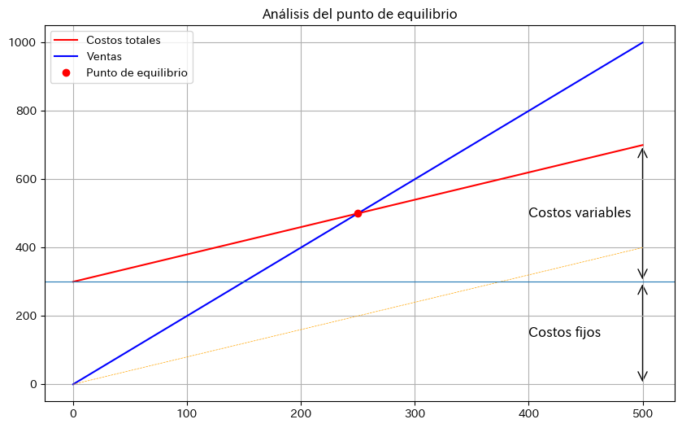

```python
from matplotlib.patches import FancyArrowPatch

# Definición de parámetros
fixed_cost = 300  #
variable_cost_per_unit = 0.8  #
selling_price_per_unit = 2  #
variable_cost_ratio = variable_cost_per_unit / selling_price_per_unit  #

# Cálculo de punto de eaquilibrio
break_even_point_1 = fixed_cost / (selling_price_per_unit * (1 - variable_cost_ratio))
break_even_point_2 = fixed_cost / (1 - variable_cost_ratio)

# Cálculo de la producción, los costos y los ingresos
production_volumes = np.linspace(0, 2 * break_even_point_1, 100)
total_costs = fixed_cost + variable_cost_per_unit * production_volumes
total_revenues = selling_price_per_unit * production_volumes
variable_costs = variable_cost_per_unit * production_volumes

# Glaph
plt.figure(figsize=(10, 6))
plt.plot(production_volumes, total_costs, label='Costos totales', color='red')
plt.plot(production_volumes, total_revenues, label='Ventas', color='blue')
plt.plot(production_volumes, variable_costs, color='orange', linewidth=0.5, linestyle='--')
plt.axhline(y=fixed_cost, linewidth=0.8)
plt.plot(break_even_point_1,break_even_point_2, 'ro', label='Punto de equilibrio')

arrow = FancyArrowPatch(posA=(500, 0), posB=(500, 300), arrowstyle='<->', mutation_scale=20)
plt.gca().add_patch(arrow)
plt.text(400, 150, 'Costos fijos', fontsize=12, verticalalignment='center')

arrow = FancyArrowPatch(posA=(500, 300), posB=(500, 700), arrowstyle='<->', mutation_scale=20)
plt.gca().add_patch(arrow)
plt.text(400, 500, 'Costos variables', fontsize=12, verticalalignment='center')

plt.title('Análisis del punto de equilibrio')
plt.legend()
plt.grid(True)
```

## 5.9 VE(Value Engineering)

機能達成にかかっている現状コストと本来の各機能が果たすためにかけなければならないコスト、すなわち目標コストを比較し、各機能の改善余地を明確にするために、機能評価をおこなう。

各機能分野の価値指数、改善余地を比較し、優先的に攻める機能分野を選択する。

Se realiza una evaluación de las funciones para comparar el costo actual necesario para lograr las funcionalidades y el costo ideal que cada función debe tener para cumplir su propósito, es decir, el costo objetivo, con el fin de identificar las áreas de mejora de cada función.

Se comparan los índices de valor y el margen de mejora de cada área funcional, y se selecciona el área funcional que debe ser priorizada para la mejora.

```python
folder_name = 'Data'
ensure_and_move_to_folder(folder_name)
```

```
Folder 'Data' already exists.
```

```python
import polars as pl

url = "https://docs.google.com/spreadsheets/d/1Ma7ehT4TAnkUwJjspP-C3mwJA1hYmbJr8B9GJSFI0lU/edit?usp=sharing"
ss = gc.open_by_url(url)

# Obtener los datos (como lista)
st = ss.worksheet("Sheet2")
list_of_lists = st.get_all_values()

df = pd.DataFrame.from_records(list_of_lists)
df.columns = df.iloc[0]
df = df.drop(index=0)

# Establecer la primera columna como índice
df = df.set_index(df.columns[0])
df.iloc[:,1:] = df.iloc[:,1:].apply(pd.to_numeric)

data = df.copy()
data['Indice de valor'] = data['Cost objetivo'] / data['Cost actual']
data['Cantidad de margen de mejora'] = data['Cost actual'] - data['Cost objetivo']
data.loc['Total'] = data.sum()
data.iat[4,0] = '-'
data['Indice de valor'] = data['Indice de valor'].apply(lambda x:round(x,2))
data['Cantidad de margen de mejora'] = data['Cantidad de margen de mejora'].apply(lambda x:round(x,2))
#data = df.with_columns(pl.col("Indice de valor").round(2))
data.to_excel("Data/5_9.xlsx")

print("Tabla de evaluación funcional:")
data
```

```
Tabla de evaluación funcional:
```

|  | Ámbito funcional | Contribución funcional (%) | Cost actual | Cost objetivo | Indice de valor | Cantidad de margen de mejora |
| --- | --- | --- | --- | --- | --- | --- |
| 0 | A1 | 32 | 320 | 300 | 0.94 | 20 |
| 1 | A2 | 32 | 320 | 250 | 0.78 | 70 |
| 2 | A3 | 24 | 240 | 60 | 0.25 | 180 |
| 3 | A4 | 12 | 120 | 30 | 0.25 | 90 |
| Total | - | 100 | 1000 | 640 | 2.22 | 360 |

```python
# Índice_de_valor
df['Índice de valor'] = df['Cost objetivo'] / df['Cost actual']

# Cantidad de margen de mejora
df['Cantidad de margen de mejora'] = df['Cost actual'] - df['Cost objetivo']

# Índice_de_valor,Cantidad de margen de mejora
print("\nÍndice_de_valor, Cantidad de margen de mejora:")
for index, row in df.iterrows():
    print(f"Ámbito funcional: {row['Ámbito funcional']}, Índice de_ alor: {row['Índice de valor']:.2f}, Cantidad de margen de mejora: {row['Cantidad de margen de mejora']}")

# Cálculo de prioridad (cuando menor esa el Índice de valor, mayor será la prioridad)
# Determinar la prioridad con un indicador que se obtiene tomando el recíproco del Índice de valor
# y multiplicándolo por la Cantidad de margen de mejora
df['Puntuación de prioridad'] = (1 / df['Índice de valor']) * df['Cantidad de margen de mejora']

df = df.sort_values(by='Puntuación de prioridad', ascending=False)

df[['Índice de valor','Puntuación de prioridad']] = df[['Índice de valor','Puntuación de prioridad']].apply(lambda x: x.map(lambda y: round(y, 2)))

print("\nTabla de prioridades:")
df[['Ámbito funcional', 'Índice de valor', 'Cantidad de margen de mejora', 'Puntuación de prioridad']]
```

```
Índice_de_valor, Cantidad de margen de mejora:
Ámbito funcional: A1, Índice de_ alor: 0.94, Cantidad de margen de mejora: 20
Ámbito funcional: A2, Índice de_ alor: 0.78, Cantidad de margen de mejora: 70
Ámbito funcional: A3, Índice de_ alor: 0.25, Cantidad de margen de mejora: 180
Ámbito funcional: A4, Índice de_ alor: 0.25, Cantidad de margen de mejora: 90

Tabla de prioridades:
```

|  | Ámbito funcional | Índice de valor | Cantidad de margen de mejora | Puntuación de prioridad |
| --- | --- | --- | --- | --- |
| 2 | A3 | 0.25 | 180 | 720.00 |
| 3 | A4 | 0.25 | 90 | 360.00 |
| 1 | A2 | 0.78 | 70 | 89.60 |
| 0 | A1 | 0.94 | 20 | 21.33 |

## 5.10

X、Yの二つの製品を製造する工場がある。各製品１単位をつくるための原材料A,Bの使用量、原料A、Bの月当たりの使用量の上限が与えられている。また、製品Xは一単位の販売につき一万円、製品Yは２万円の利益が見込まれる。このとき、利益を最大にする製品ＸとＹの製造量、ｘ単位とｙ単位を求めよ。

Hay una fábrica que produce dos productos, X y Y. Se nos dan las cantidades de materiales A y B que se utilizan para producir una unidad de cada producto, así como los límites de uso mensual de los materiales A y B. Además, se espera que el beneficio por la venta de una unidad del producto X sea de 10,000 yenes y el beneficio por la venta de una unidad del producto Y sea de 20,000 yenes. En este caso, se debe determinar la cantidad de productos X (x unidades) e Y (y unidades) a producir para maximizar el beneficio.

```
Optimal value: 200.0 with x: 12.0 and y: 4.0
Beneficio con la cantidad óptima de producción: z = 10 * 12.00 + 20 * 4.00 = 200.00 万円
```

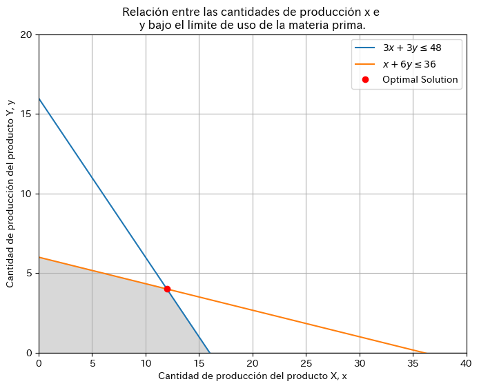

```python
from scipy.optimize import linprog

# Función objetivo (dado que se desea maximizar el beneficio, ya que
# scipy.optimize.linprog minimiza, se inverte el signo)
c = [-10, -20]  # -x - 2y

# Condiciones de restricción
A = [[3, 3],  # 3x + 3y <= 48
     [1, 6]]  # x + 6y <= 36
b = [48, 36]

# Restricciones deno negatividad de las variables
x0_bounds = (0, None)
x1_bounds = (0, None)

# Resolver el problema de programación lineal
res = linprog(c, A_ub=A, b_ub=b, bounds=[x0_bounds, x1_bounds], method='highs')

# Salida de la solución óptima
print('Optimal value:', -res.fun, 'with x:', res.x[0], 'and y:', res.x[1])

# Función para calcular la cantidad óptima de producción
x_optimal = res.x[0]
y_optimal = res.x[1]

# x unidades de producto X y y unidades de producto Y
def calculate_profit(x, y):
    return 10 * x + 20 * y

# Calcular el benificio con la cantidad óptima de producción
profit_optimal = calculate_profit(x_optimal, y_optimal)
print(f"Beneficio con la cantidad óptima de producción: z = 10 * {x_optimal:.2f} + 20 * {y_optimal:.2f} = {profit_optimal:.2f} 万円")

# Creación de gráfico
x = np.linspace(0, 40, 400)

# Línea de frontera de la restricciones
y1 = (48 - 3 * x) / 3
y2 = (36 - 1 * x) / 6

plt.figure(figsize=(8, 6))

# Área factible sombreada
plt.fill_between(x, np.minimum(y1, y2), color='grey', alpha=0.3)

# Trazar las líneas de frontera
plt.plot(x, y1, label=r'$3x + 3y \leq 48$')
plt.plot(x, y2, label=r'$x + 6y \leq 36$')

# Establecer las marcas del eje x y del eje y en intervalos de 5 unidades
plt.xlim(0, 40)
plt.ylim(0, 20)

# Trazar la solución óptima
plt.plot(res.x[0], res.x[1], 'ro', label='Optimal Solution')

# Establecer las marcas del eje x y del eje y en intervalos de 5 unidades
plt.xticks(np.arange(0,41, 5))
plt.yticks(np.arange(0, 21, 5))

# Etiquetas y títlo
plt.xlabel('Cantidad de producción del producto X, x')
plt.ylabel('Cantidad de producción del producto Y, y')
plt.title('Relación entre las cantidades de producción x e \ny bajo el límite de uso de la materia prima.')
plt.legend()
plt.grid()
```

```python
!pip install pulp
```

```python
url = "https://docs.google.com/spreadsheets/d/1Ma7ehT4TAnkUwJjspP-C3mwJA1hYmbJr8B9GJSFI0lU/edit?usp=sharing"
ss = gc.open_by_url(url)

# Obtener los datos (como lista)
st = ss.worksheet("Sheet4")
list_of_lists = st.get_all_values()

df = pd.DataFrame.from_records(list_of_lists)
df.columns = df.iloc[0]
df = df.drop(index=0)

# Establecer la primera columna como índice
df = df.set_index(df.columns[0])
df = df.apply(pd.to_numeric)
df
```

|  | X | Y | Stock |
| --- | --- | --- | --- |
| A | 3 | 3 | 48.0 |
| B | 1 | 6 | 36.0 |
| Venefit | 10 | 20 | NaN |

```python
import pulp

P = df.columns[:2].to_list()
M = df.index[:2].to_list()
stock = dict(df['Stock'][:2])
gain = dict(df.loc['Venefit'][:2])
require = {(p, m): df.loc[m, p] for p in P for m in M}

x = {}
for p in P:
  x[p] = pulp.LpVariable(p, lowBound=0, cat='Continuous')
```

```python
problem = pulp.LpProblem("Maximize_gain", pulp.LpMaximize)

for m in M:
  for p in P:
    problem += pulp.lpSum([require[(p,m)] * x[p] for p in P]) <= stock[m]

problem += pulp.lpSum([gain[p]*x[p] for p in P])

status = problem.solve()
print(pulp.LpStatus[status])
```

```
Optimal
```

```python
for p in P:
  print(p, x[p].value())
print("obj=", problem.objective.value())
```

```
X 12.0
Y 4.0
obj= 200.0
```